# Jakob Bindas CS 1675 Final Project

#### Perform logit-transform on response

```r
df_logit <- df %>%
  mutate(
    y = boot::logit((response - 0) / (100 - 0)) # formula from slide 13 of instruction slides
  )
```

#### Visualize logit transformed response with continuous variables

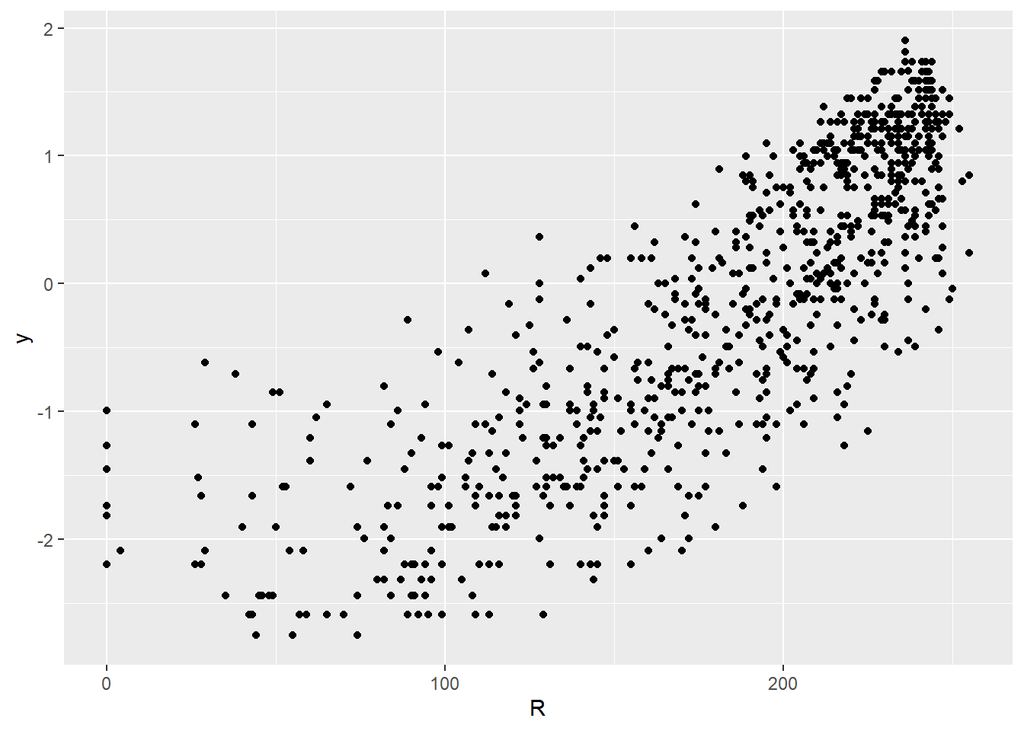

```r
df_logit %>%
  ggplot(mapping=aes(x=R, y=y)) +
  geom_point()
```

There is a moderate correlation between R and y.

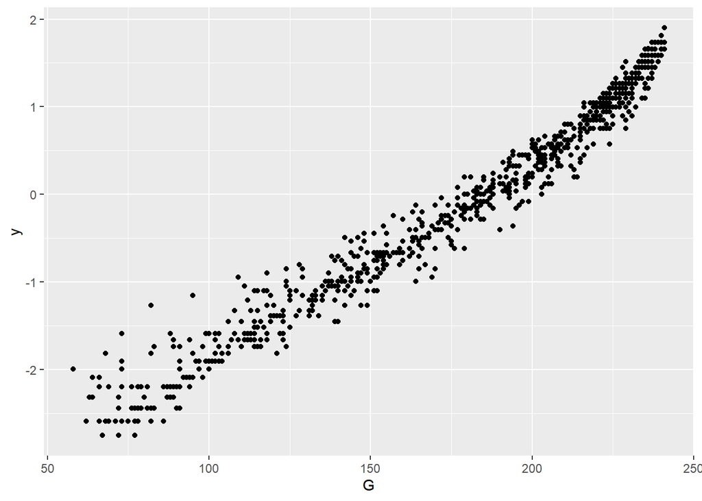

```r
df_logit %>%
  ggplot(mapping=aes(x=G, y=y)) +
  geom_point()
```

There is a strong correlation between G and y.

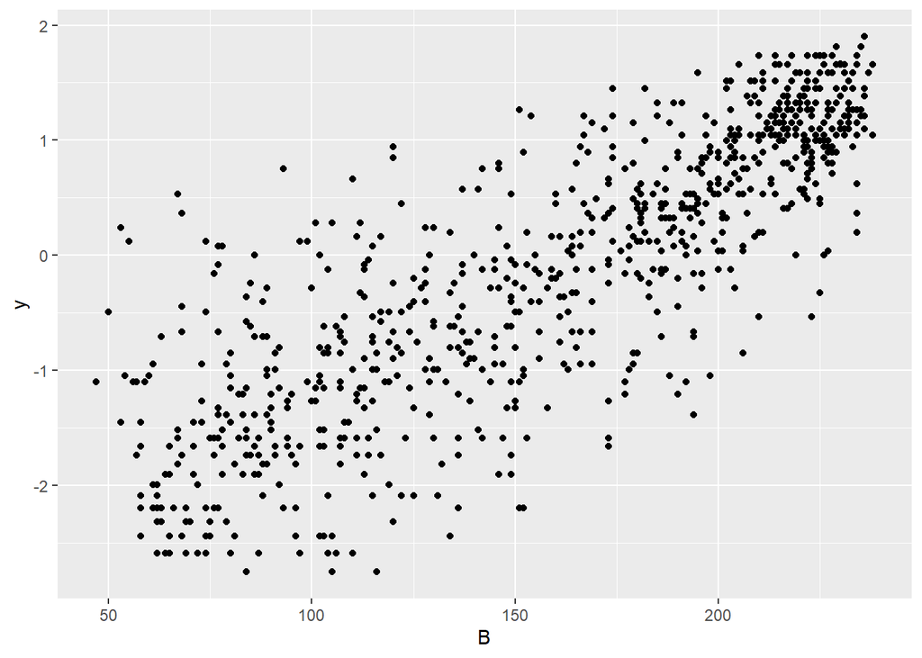

```r
df_logit %>%
  ggplot(mapping=aes(x=B, y=y)) +
  geom_point()
```

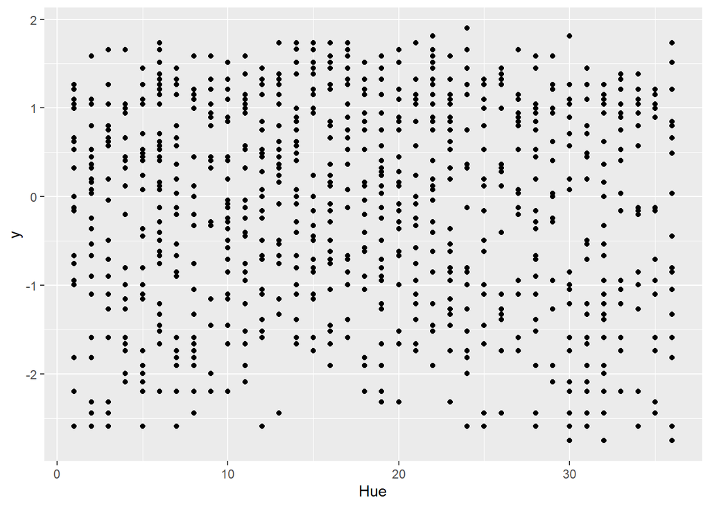

```r
df_logit %>%
  ggplot(mapping=aes(x=Hue, y=y)) +
  geom_point()
```

There is no correlation between Hue and y.

#### Now, visualize each of the above based on categorical variables

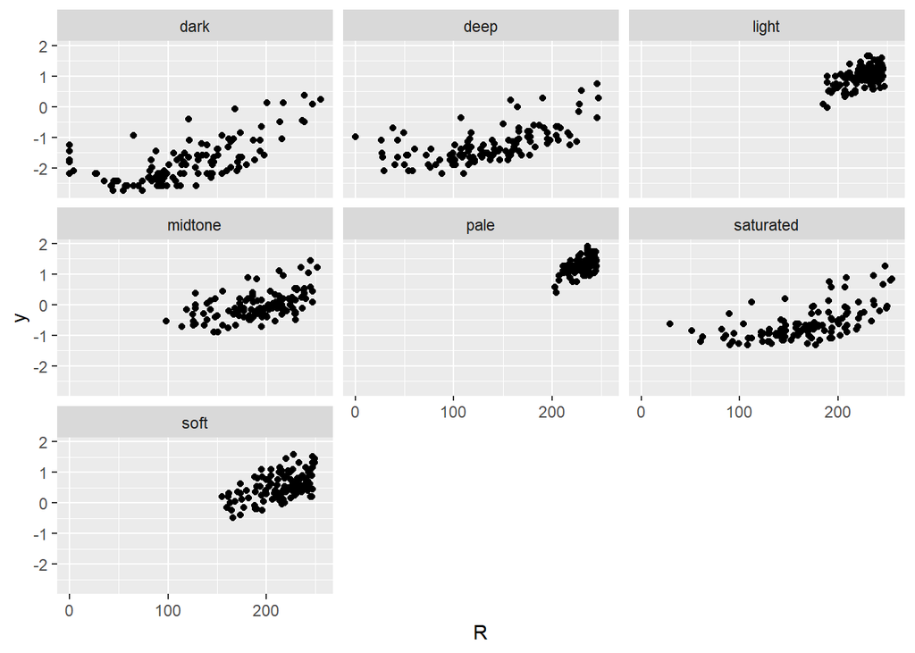

```r
df_logit %>%
  ggplot(mapping=aes(x=R, y=y)) +
  geom_point() +
  facet_wrap(~Lightness)
```

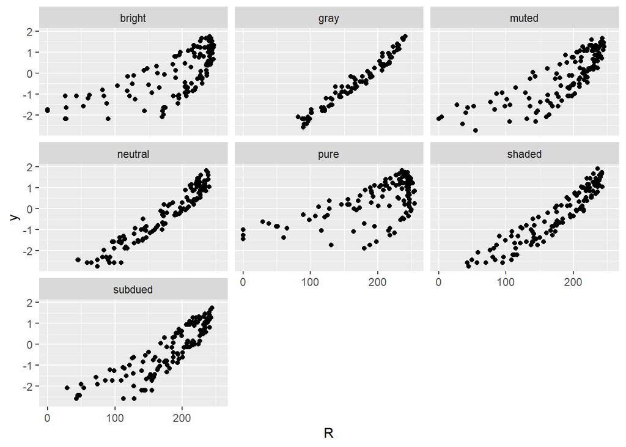

```r
df_logit %>%
  ggplot(mapping=aes(x=R, y=y)) +
  geom_point() +
  facet_wrap(~Saturation)
```

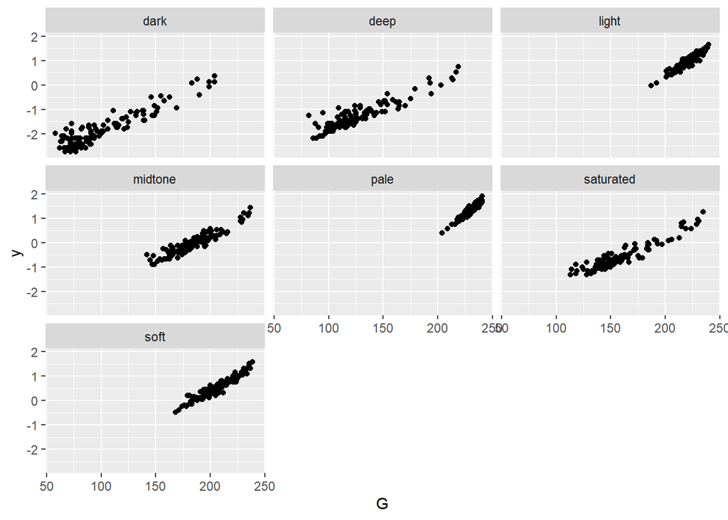

```r
df_logit %>%
  ggplot(mapping=aes(x=G, y=y)) +
  geom_point() +
  facet_wrap(~Lightness)
```

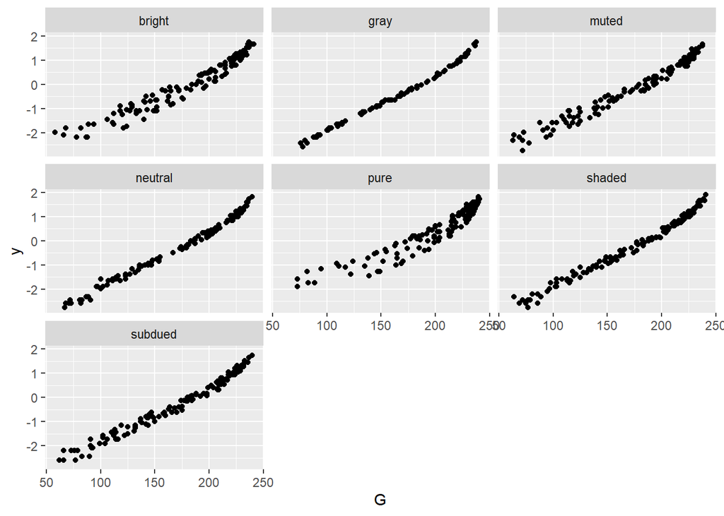

```r
df_logit %>%
  ggplot(mapping=aes(x=G, y=y)) +
  geom_point() +
  facet_wrap(~Saturation)
```

Conditioning on Lightness and Saturation doesn’t really change anything regarding the strength of the trend between G and y.

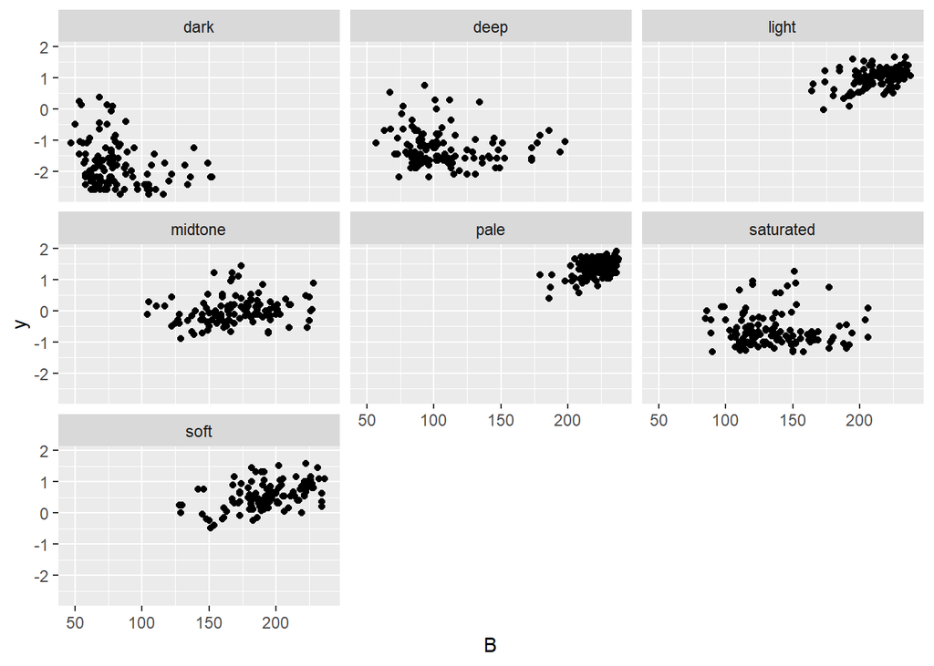

```r
df_logit %>%
  ggplot(mapping=aes(x=B, y=y)) +
  geom_point() +
  facet_wrap(~Lightness)
```

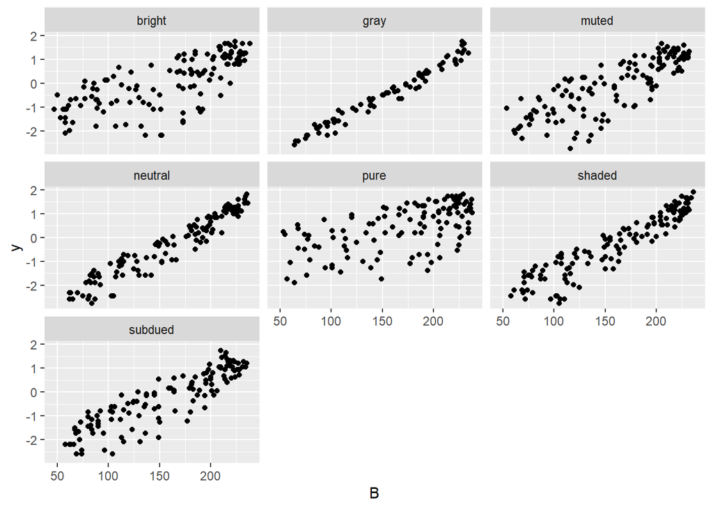

```r
df_logit %>%
  ggplot(mapping=aes(x=B, y=y)) +
  geom_point() +
  facet_wrap(~Saturation)
```

Conditioning on Saturation seems to strengthen the relationship between B and y in some cases, while weakening it in others.

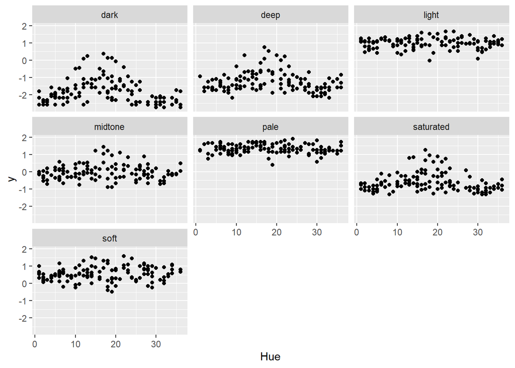

```r
df_logit %>%
  ggplot(mapping=aes(x=Hue, y=y)) +
  geom_point() +
  facet_wrap(~Lightness)
```

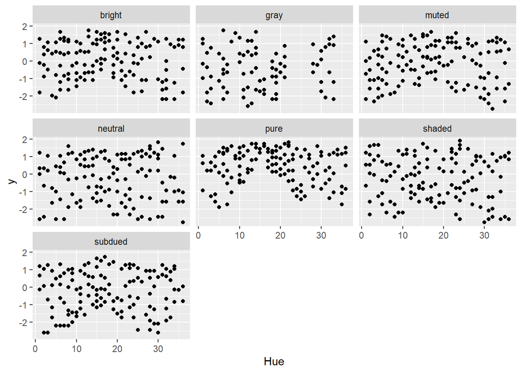

```r
df_logit %>%
  ggplot(mapping=aes(x=Hue, y=y)) +
  geom_point() +
  facet_wrap(~Saturation)
```

Conditioning by Lightness appears to reveal some Gaussianity in each sub-distribution between Hue and y. Saturation still appears to be mostly random.

Overall, there is a tight relationship with gray for R, G and B. The lightness of R, G and B all appear to be clustering close to some value for the given lightness value.

### E. Visualize outcome with respect to the continuous inputs

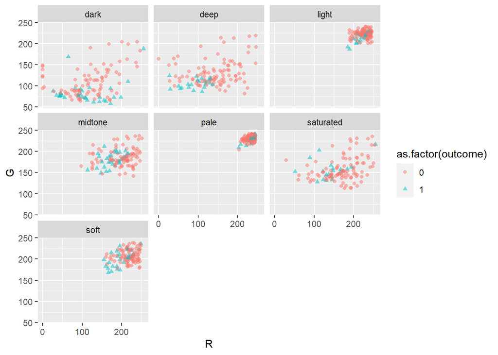

```r
df %>%
  ggplot(mapping=aes(x=R, y=G)) +
  geom_point(mapping=aes(color=as.factor(outcome), shape=as.factor(outcome)), alpha=0.5) +
  facet_wrap(~Lightness)
```

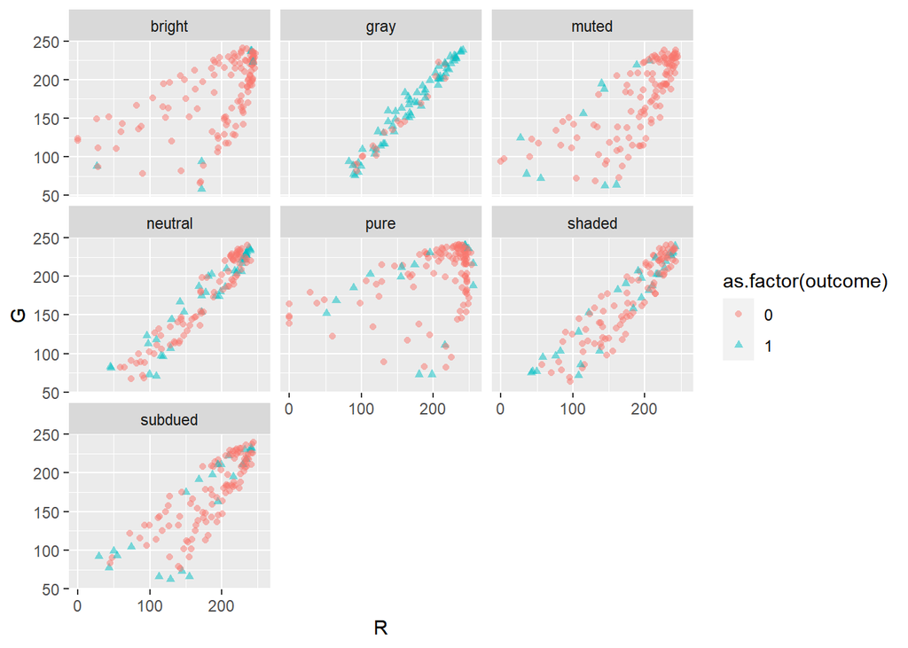

```r
df %>%
  ggplot(mapping=aes(x=R, y=G)) +
  geom_point(mapping=aes(color=as.factor(outcome), shape=as.factor(outcome)), alpha=0.5) +
  facet_wrap(~Saturation)
```

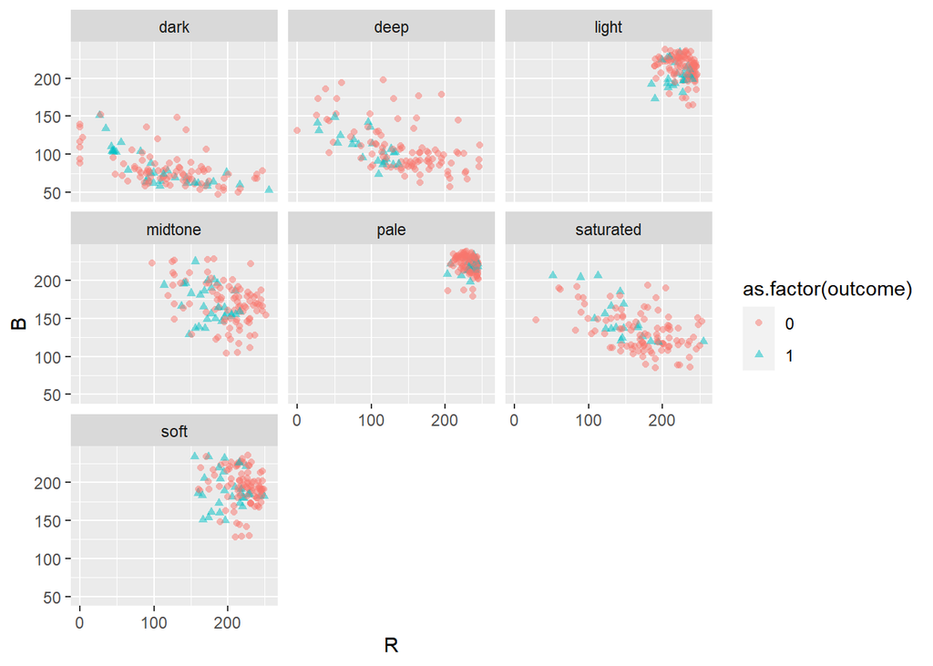

```r
df %>%
  ggplot(mapping=aes(x=R, y=B)) +
  geom_point(mapping=aes(color=as.factor(outcome), shape=as.factor(outcome)), alpha=0.5) +
  facet_wrap(~Lightness)
```

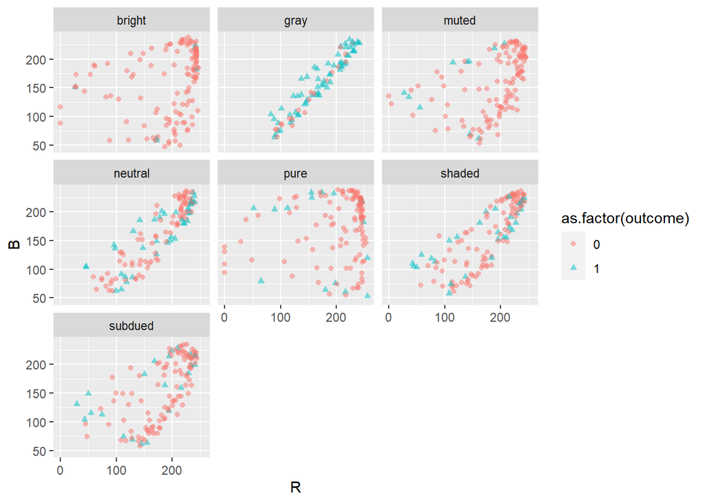

```r
df %>%
  ggplot(mapping=aes(x=R, y=B)) +
  geom_point(mapping=aes(color=as.factor(outcome), shape=as.factor(outcome)), alpha=0.5) +
  facet_wrap(~Saturation)
```

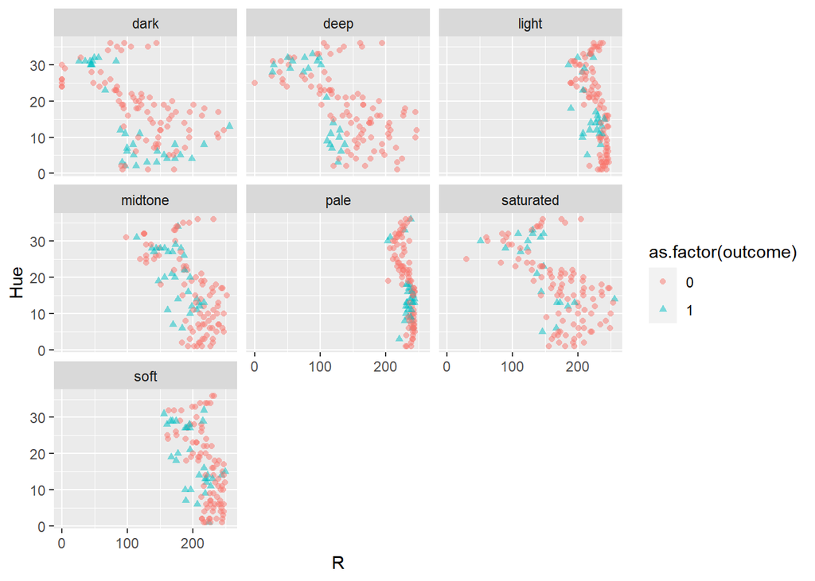

```r
df %>%
  ggplot(mapping=aes(x=R, y=Hue)) +
  geom_point(mapping=aes(color=as.factor(outcome), shape=as.factor(outcome)), alpha=0.5) +
  facet_wrap(~Lightness)
```

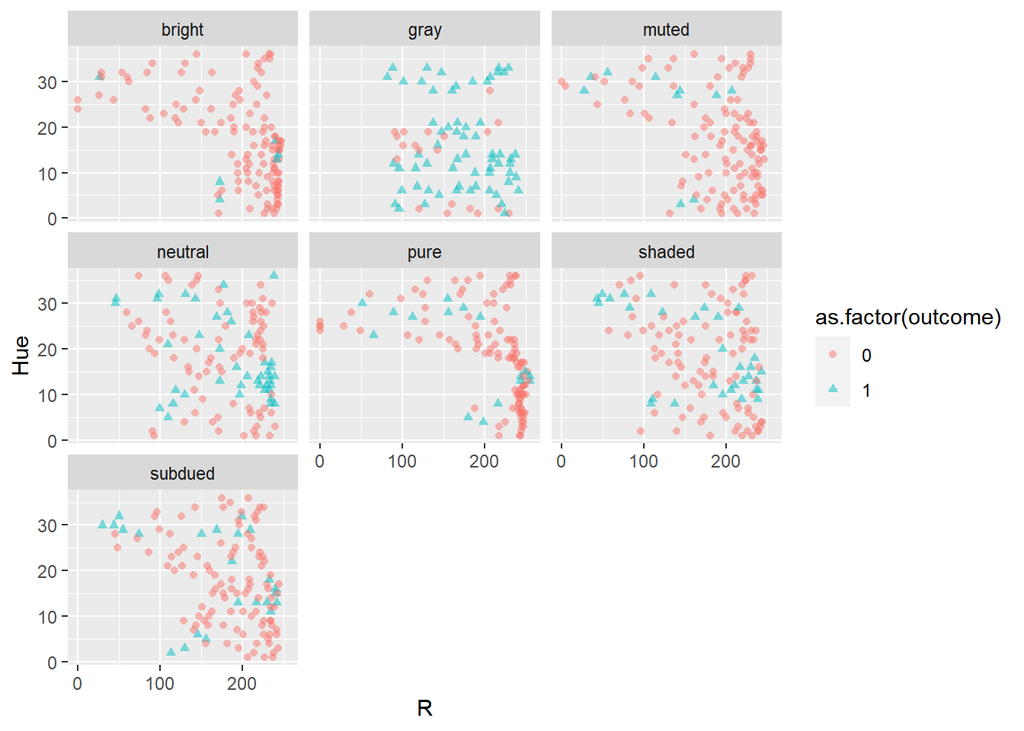

```r
df %>%
  ggplot(mapping=aes(x=R, y=Hue)) +
  geom_point(mapping=aes(color=as.factor(outcome), shape=as.factor(outcome)), alpha=0.5) +
  facet_wrap(~Saturation)
```

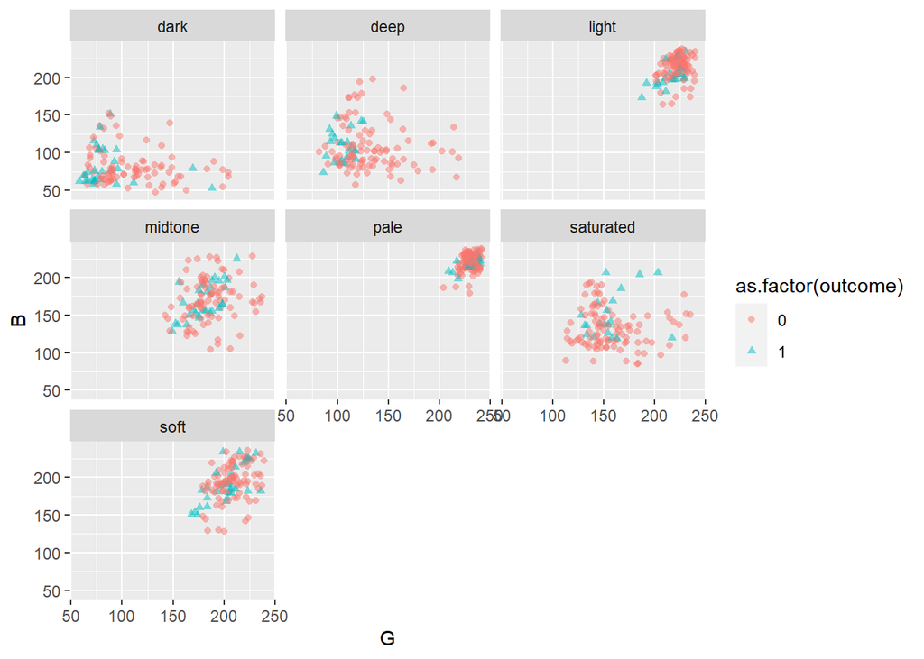

```r
df %>%
  ggplot(mapping=aes(x=G, y=B)) +
  geom_point(mapping=aes(color=as.factor(outcome), shape=as.factor(outcome)), alpha=0.5) +
  facet_wrap(~Lightness)
```

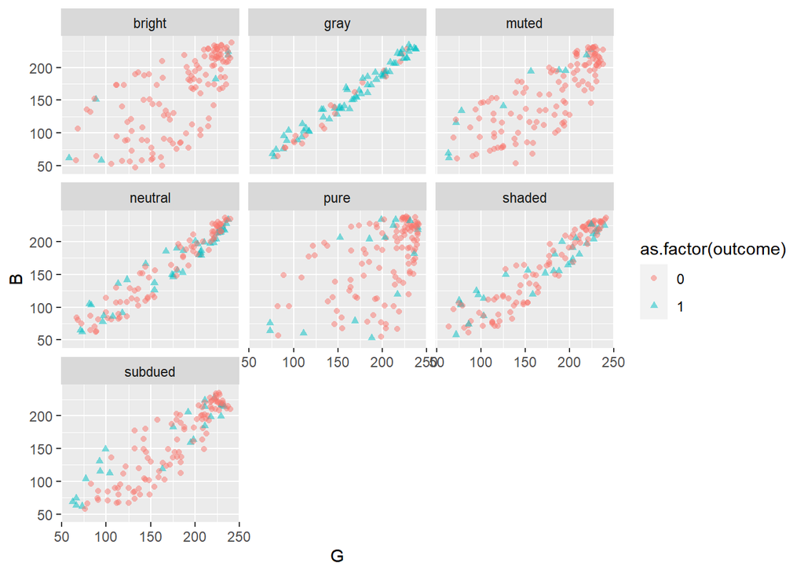

```r
df %>%
  ggplot(mapping=aes(x=G, y=B)) +
  geom_point(mapping=aes(color=as.factor(outcome), shape=as.factor(outcome)), alpha=0.5) +
  facet_wrap(~Saturation)
```

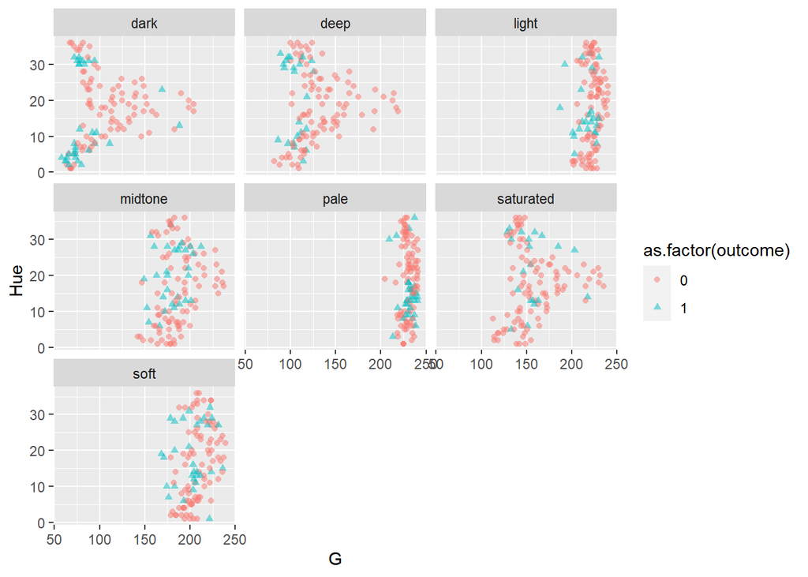

```r
df %>%
  ggplot(mapping=aes(x=G, y=Hue)) +
  geom_point(mapping=aes(color=as.factor(outcome), shape=as.factor(outcome)), alpha=0.5) +
  facet_wrap(~Lightness)
```

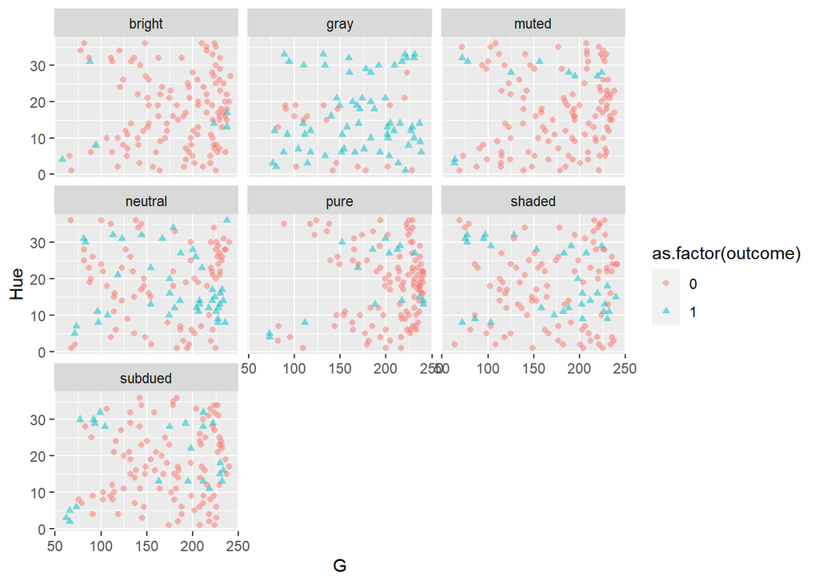

```r
df %>%
  ggplot(mapping=aes(x=G, y=Hue)) +
  geom_point(mapping=aes(color=as.factor(outcome), shape=as.factor(outcome)), alpha=0.5) +
  facet_wrap(~Saturation)
```

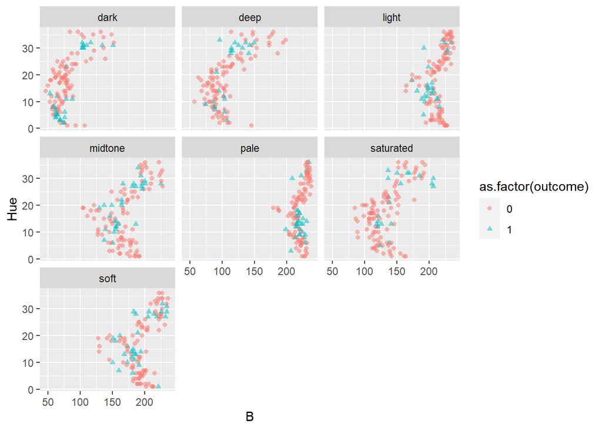

```r
df %>%
  ggplot(mapping=aes(x=B, y=Hue)) +
  geom_point(mapping=aes(color=as.factor(outcome), shape=as.factor(outcome)), alpha=0.5) +
  facet_wrap(~Lightness)
```

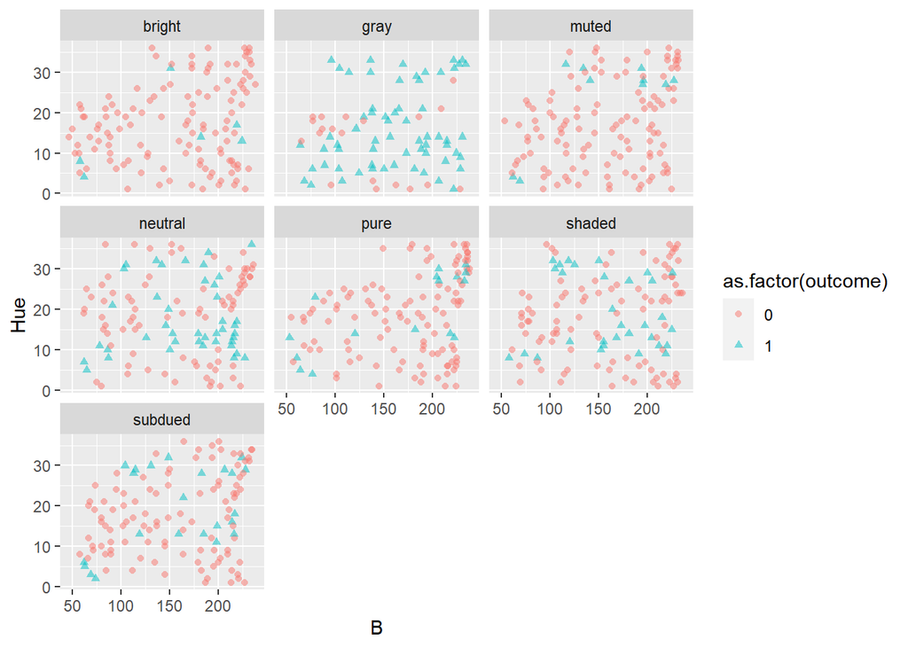

```r
df %>%
  ggplot(mapping=aes(x=B, y=Hue)) +
  geom_point(mapping=aes(color=as.factor(outcome), shape=as.factor(outcome)), alpha=0.5) +
  facet_wrap(~Saturation)
```

We can see that in every case, the outcome appears most often when the Saturation is gray, neutral or shaded with the Lightness appearing to be roughly consistent across the grid for each variable.